# Sprawozdanie 2

# ZADANIE 3 (Skalowaniewielowymiarowe (Multidimensional Scaling (MDS)))

## a) Dane: titanic_train (R-pakiet titanic)

Zbiór danych zawiera wybrane charakterystyki opisujące pasażerów Titanica (w tym m.in. takie zmienne jak: wiek, płeć, miejsce rozpoczęcia podróży czy klasa pasażerska) wraz z informacją czy dana osoba przeżyła katastrofę (zmienna Survived).

## b) Przygotowanie danych

Wczytane dane, niepotrzebne kolumny zostały usunięte, oraz typy poszczególnych cech zostały zaaktualizowane na odpowiednie czyt. ordered,numeric

## c) Redukcja wymiaru na bazie MDS

Redukuję wymiar danych korzystając z **metody metrycznej (Funkcja cmdscale)**

Kolejno tworzymy diagram Shepherda

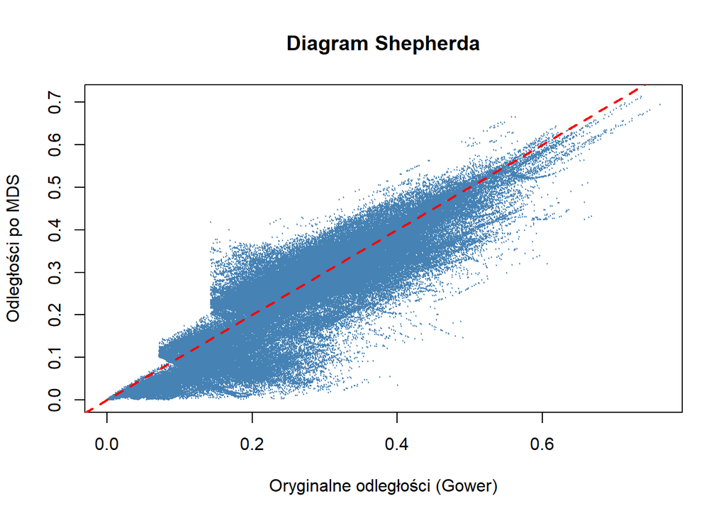

Widać, że odległości w nowej przestrzeni danych **zmieniły się**. Nadal mają podobny charakter ponieważ największe skupisko danych znajduje się przy prostej **x = y** (gdyby odległości zostały zachowane, czyli w idealnym scenariuszu, to nasze nowe odległości przechodziły by właśnie przez tę linię).

Pomimo, że duża liczba punktów **odbiega** od prostej **x = y**, to jednak różnica między ich nową odległością a starą w większości nie jest duża (nie mamy znaczących rozrzutów na osi OY), więc możemy uznać skalowanie za dopuszalnie dobrą metodę.

## d) Wizualizacja danych

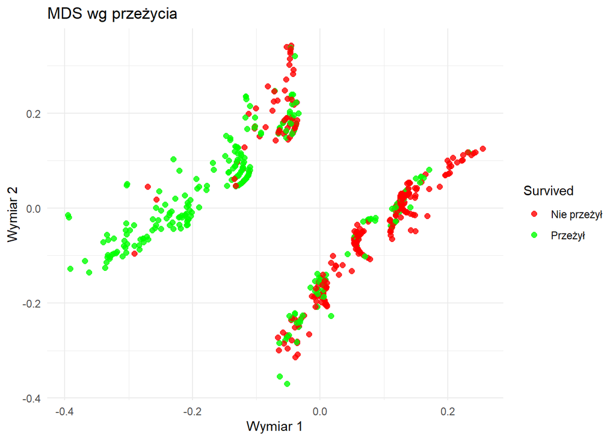

Widoczny podział obiektów na grupy: pierwsze zagęszczenie charakteryzuje się dużą przeżywalnością a drugie o wiele mniejszą.

Na wykresach nie ma obserwacji odstajacych, bądź nietypowych.

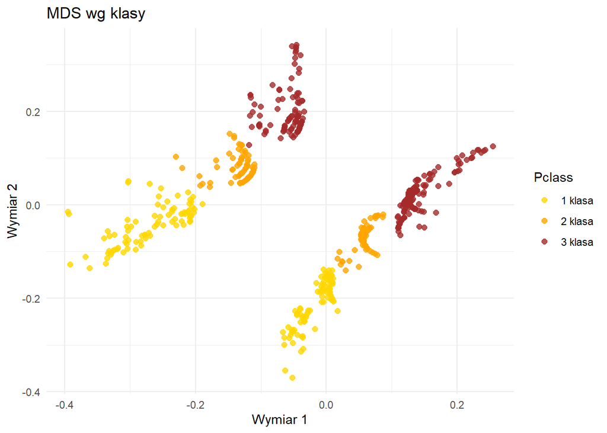

**Równomierny rozkład**, grupy nie są zależne od tego w jakiej klasie ktoś płyną

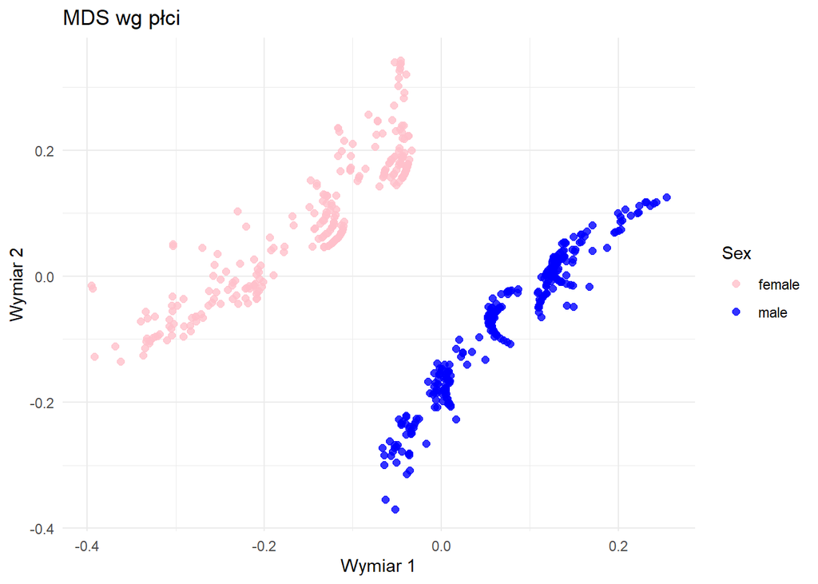

Widać bardzo jasny podział na kobiety i mężczyzn. Porównując do porzedniego wykresu widać, że większą przeżywalnością charakteryzuje się grupa kobiet, co jest zgodne z intuicją i rzeczywistymi danymi.